# Testing Alternate Method to Simulate Nu Values

Kevin R. Coombes

24 October 2017

# Introduction

We observed that running the `pairedStat` function in the `NewmanOmics` package was quite slow. By profiling the code, we learned that almost all of the time was spent in the call to the `loess` function inside the routine `randNuGen`. We hypothesized that replacing the local smoothing function by a simple global estimate (using the mean) would speed up the code considerably without changing the results very much. In this report, we want to test that hypothesis.

# Testing

We begin by loading our standard example for the paired statistic.

```r
library(NewmanOmics)
csvfile <- system.file("extdata", "LungNormalTumorPair.csv",
                       package="NewmanOmics")
lung <- read.csv(csvfile)
summary(lung)
```

```
##         Gene.ID      TCGA.38.4625.11A.01R.1758.07
##  ?|100130426:    1   Min.   :     0.0
##  ?|100133144:    1   1st Qu.:     5.5
##  ?|100134869:    1   Median :   177.6
##  ?|10357    :    1   Mean   :  1216.7
##  ?|10431    :    1   3rd Qu.:   773.4
##  ?|136542   :    1   Max.   :517227.5
##  (Other)    :20525
##  TCGA.38.4625.01A.01R.1758.07
##  Min.   :     0.0
##  1st Qu.:     7.2
##  Median :   210.9
##  Mean   :  1152.7
##  3rd Qu.:   850.5
##  Max.   :839878.9
##
```

Next, we use the existing code, which relies on the loess function. On my laptop, this takes about 90 seconds to run.

```r
set.seed(12345)
picked <- sample(nrow(lung), 1000)
normal <- log(1 + as.matrix(lung[picked, 2, drop=FALSE]))
tumor  <- log(1 + as.matrix(lung[picked, 3, drop=FALSE]))
tic <- proc.time()
ps <- pairedStat(normal, tumor)
elapsed <- proc.time() - tic
elapsed
```

```
##    user  system elapsed
##   91.47    1.13   92.74
```

Now we define our new version of the algorithm.

```r
altmeth <- function(mu = 0, sigma = 1) {
  A <- matrix(rnorm(10000*100, mu, sigma), ncol=100)
  B <- matrix(rnorm(10000*100, mu, sigma), ncol=100)
  sdest <- mean( abs(A-B)/sqrt(2) )
  abs(A-B)/sdest
}
```

We manually run the last part of the code, as extracted from the `pairedStat` function. This should only ake about 5 or 6 seconds

```r
tic <- proc.time()
m <- mean(ps$nu.statistics)
sd <- sd(ps$nu.statistics)
randNu <- altmeth(m, sd)
pValsPaired <- NewmanOmics:::nu2PValPaired(ps$nu.statistics,
                                           as.vector(randNu))
elapsed <- proc.time() - tic
elapsed
```

```
##    user  system elapsed
##    5.47    1.06    6.53
```

Now we can look at the results. First, we check grossly to see if the values look very different.

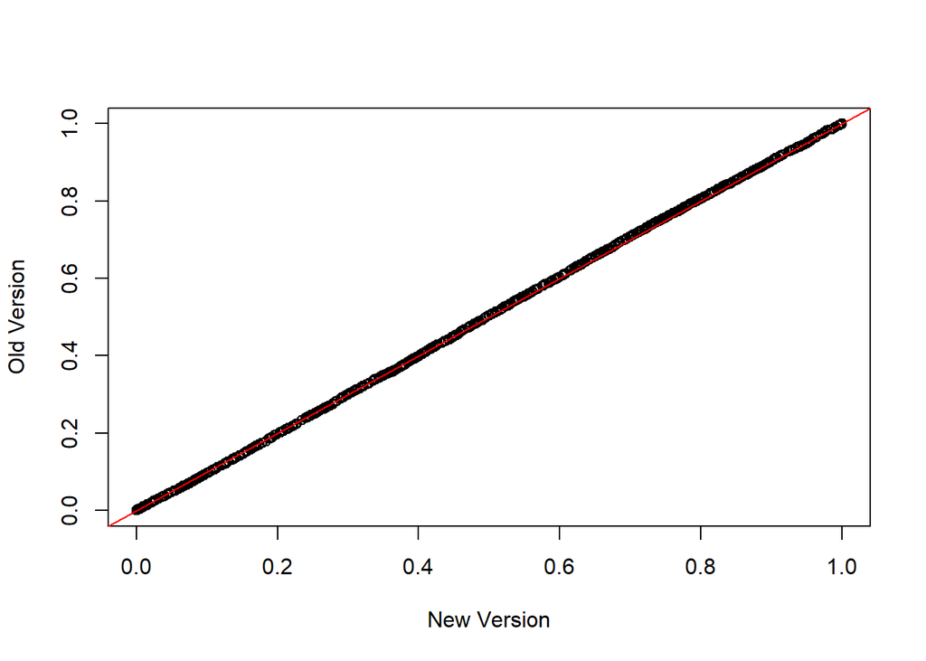

Scatter plot of two versions of empirical p-values

```r
plot(pValsPaired, ps$p.values,
     xlab="New Version", ylab="Old Version")
abline(0,1, col='red')
```

On this scale, the differences in the p-values are too small to matter. But we can check the actual size.

```r
summary(as.vector(pValsPaired - ps$p.values))
```

```
##       Min.    1st Qu.     Median       Mean    3rd Qu.       Max.
## -0.0091920 -0.0045417 -0.0004525 -0.0016255  0.0007875  0.0052320
```

So, the differences look like they vary less than about 0.01, which may be a little bigger than we’d like to see. To get a different view of the data, we can plot the differences as a function of the “old” definition of p-values.

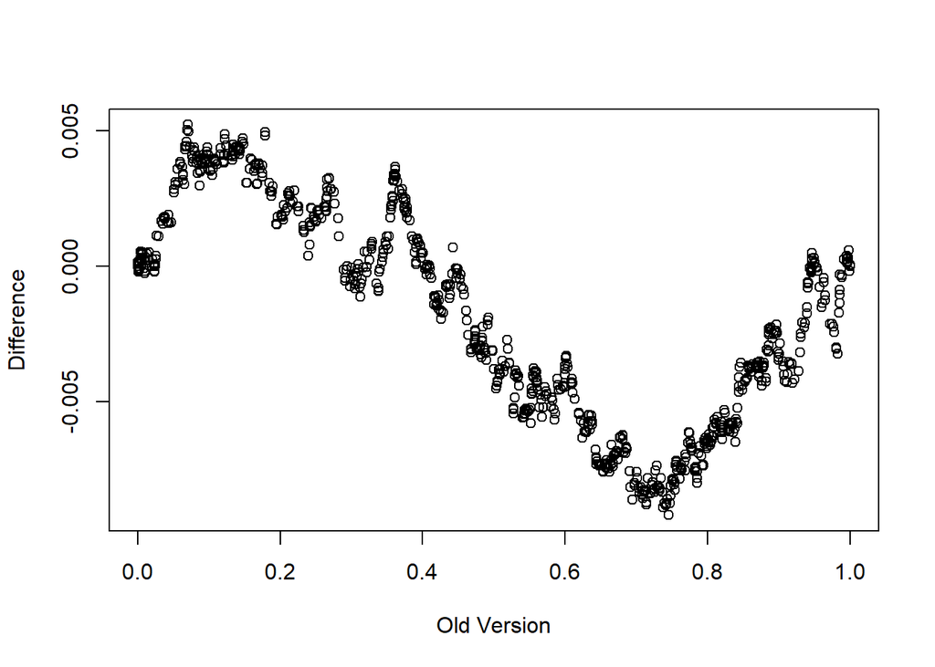

Plot of the difference in p-values.

```r
plot(ps$p.values, pValsPaired - ps$p.values,
     xlab="Old Version", ylab="Difference")
```

Hmm. There are appear to be systematic changes. This *could*, however, be a consequence of randomness in the simulations. One way to check is to repeat the computations with a different random seed.

```r
set.seed(54321)
ps2 <- pairedStat(normal, tumor)
m <- mean(ps2$nu.statistics)
sd <- sd(ps2$nu.statistics)
randNu <- altmeth(m, sd)
pValsPaired2 <- NewmanOmics:::nu2PValPaired(ps2$nu.statistics,
                                            as.vector(randNu))
summary(as.vector(pValsPaired2 - ps2$p.values))
```

```
##       Min.    1st Qu.     Median       Mean    3rd Qu.       Max.
## -5.449e-03 -9.735e-04  0.000e+00  5.594e-05  1.168e-03  4.087e-03
```

Of course, here we can also how much repeating the estimation using the same method changes.

```r
summary(as.vector(ps$p.values - ps2$p.values))
```

```
##     Min.  1st Qu.   Median     Mean  3rd Qu.     Max.
## -0.00710  0.00000  0.00140  0.00156  0.00340  0.00980
```

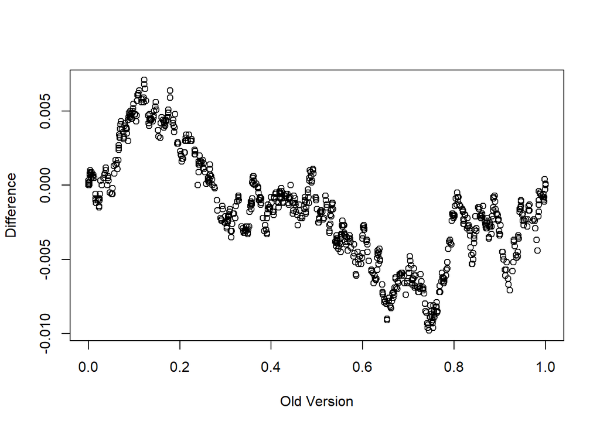

Comparison of p-values when running the old method twice.

```r
plot(ps$p.values, ps2$p.values - ps$p.values,
     xlab="Old Version", ylab="Difference")
```

Interesting. The variability in the p-values from one run to another of the old code is almost exactly the same as switching from the old slow code to the new faster code.

# Conclusion

We can safely replace the old code with the new code. However, we need to keep in mind that the empirical p-value estimates are only accurate to about 0.01 when we simualte one million fake nu-values.